# Donor Profile: France - Ministry for Europe and Foreign Affairs

## Focus Portfolio

France’s Ministry for Europe and Foreign Affairs directs a highly concentrated funding portfolio across seven UNHCR regions, totaling an average of $2.1 million per program, with peaks reaching $14.5 million. This concentration underscores a strategic priority: leveraging France’s existing major investments to scale impact in key regions with proven funding efficiency. Notably, 50% of funding is allocated to only a few projects, presenting an opportunity to optimize resource distribution and amplify outcomes through targeted donor engagement. This insight highlights a critical fundraising angle—investors can multiply impact by aligning with France’s focal regions where funds demonstrate measurable scale and resilience-building capacities. Strategic decisions should prioritize expanding partnerships in regions with mid-to-high funding levels to address potential gaps and capitalize on France’s strong funding momentum. Immediate action includes mobilizing co-investors to bridge any shortfalls and drive innovation in programming that maximizes ROI and accountability. Donors prioritizing emergency response and sustainable resilience will find compelling evidence in France’s concentrated yet scalable funding pattern, offering a clear path to leverage existing commitments into broader regional impact.

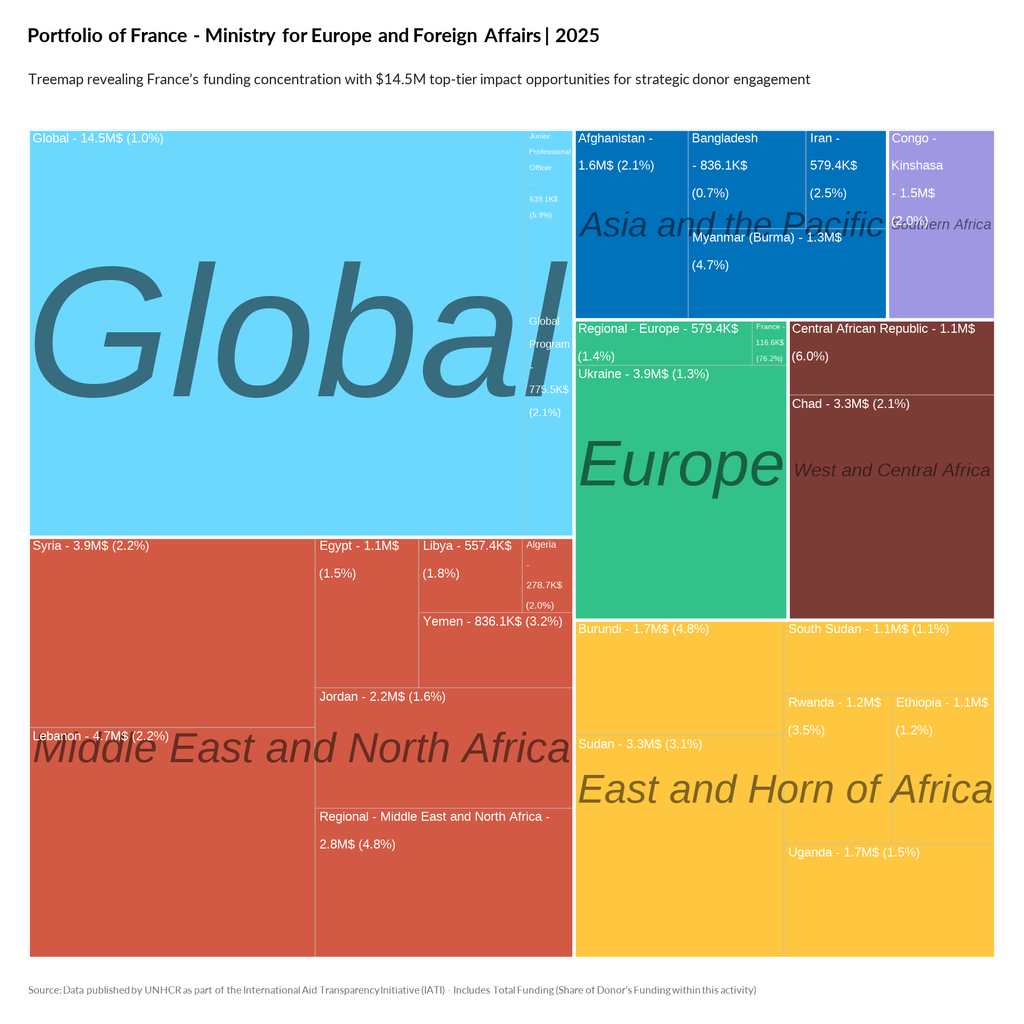

TRUE

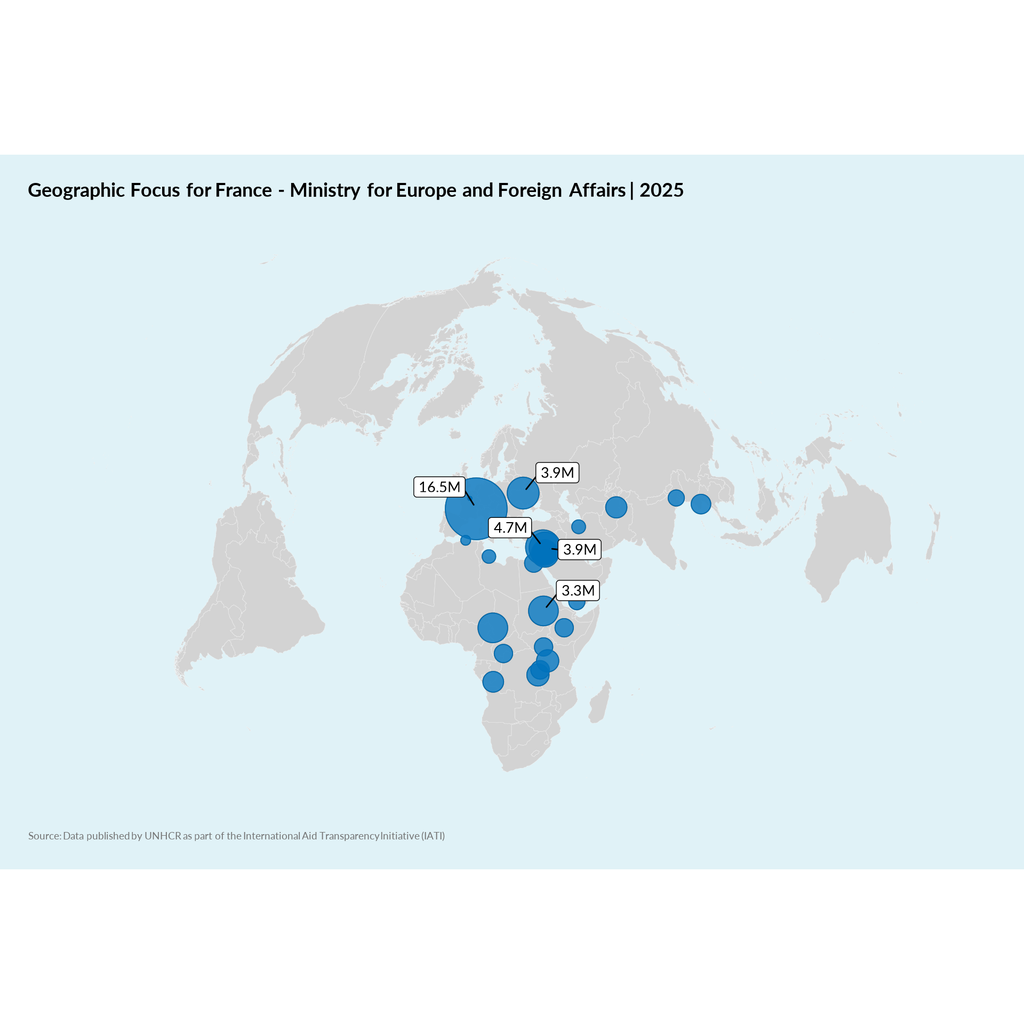

TRUE